# Clustering My Top Spotify Artists

Auggie Heschmeyer

5/24/2020

I recently discovered the [`spotifyr`](https://www.rcharlie.com/spotifyr/) package that allows you to access the Spotify API data within R. More importantly, it allows you the opportunity to download and analyze your own listening data. As a data nerd and an avid Spotify user, I thought it would make a fun exercise to see if there are any patterns within the music I listen to and if I can back up my self-described musical tastes (“alternative rock with a pop bent”) with data.

In this post I’ll take a look at my top artists and their genres to see how similar they are. In my next post, I will look at my top songs or, as Spotify calls them, *tracks*.

### Setting Up the API

I won’t go into the specifics about how to set up a developer account with Spotify because the package creators do a fine job explaining how to do so on the [`spotifyr` website](https://www.rcharlie.com/spotifyr/). Once you have your credentials, however, getting access is as simple as three lines of code.

```r
library(spotifyr)

Sys.setenv(SPOTIFY_CLIENT_ID = 'xxxxxxxxxxxxxxxxxxxxx')
Sys.setenv(SPOTIFY_CLIENT_SECRET = 'xxxxxxxxxxxxxxxxxxxxx')

access_token <- get_spotify_access_token()
```

### Getting My Top Artist Data

The `spotifyr` package contains a plethora of ways to interact with Spotify’s API, but to access my top artists, we can use the appropriately named `get_my_top_artists_or_tracks()` function. This function has a number of arguments, but the three we are most concerned with for this analysis are `type`, `limit` and `time_range`. `type` and `limit` are straightforward and allow us to define whether we want artist or track data along with how many records we want to return, respectively. We’re going to use `"artist"` and `50` as our values for this analysis.

The `time_range` argument is a little more involved. Rather than being able to specify an exact date range, `time_range` takes three possible arguments as strings: `"short_term"`, `"median_term"` or `"long_term"`. The [Spotify for Developers reference guide](https://developer.spotify.com/documentation/web-api/reference/personalization/get-users-top-artists-and-tracks/) defines these as approximately “the last 4 weeks,” “the last 6 months” and “several years,” respectively. The argument defaults to `"median_term"` and that’s what we’ll stick with today as I’m most interested in what I’ve been listening to this year.

Finally, since I am a fan of working within the `tidyverse`, we’re going to save the output of `get_my_top_artists_or_tracks()` as a tibble.

```r
library(tidyverse)

my_top_artists_tbl <- get_my_top_artists_or_tracks(
  type = "artists",
  limit = 50,
  time_range = "medium_term"
) %>%
  as_tibble()
```

Let’s take a quick `glimpse()` at our data.

```r
my_top_artists_tbl %>%
  glimpse()
```

```
## Rows: 50
## Columns: 11
## $ genres                <list> [<"indie pop", "modern alternative rock", "mod…
## $ href                  <chr> "https://api.spotify.com/v1/artists/3mIj9lX2MWu…
## $ id                    <chr> "3mIj9lX2MWuHmhNCA7LSCW", "1Xyo4u8uXC1ZmMpatF05…
## $ images                <list> [<data.frame[3 x 3]>, <data.frame[3 x 3]>, <da…
## $ name                  <chr> "The 1975", "The Weeknd", "The Band CAMINO", "C…
## $ popularity            <int> 84, 97, 68, 74, 73, 74, 64, 87, 81, 75, 95, 81,…
## $ type                  <chr> "artist", "artist", "artist", "artist", "artist…
## $ uri                   <chr> "spotify:artist:3mIj9lX2MWuHmhNCA7LSCW", "spoti…
## $ external_urls.spotify <chr> "https://open.spotify.com/artist/3mIj9lX2MWuHmh…
## $ followers.href        <lgl> NA, NA, NA, NA, NA, NA, NA, NA, NA, NA, NA, NA,…
## $ followers.total       <int> 4034348, 20472637, 163420, 1119290, 1364793, 11…
```

As you can see, we have the artist `name`, some info on their `genres` and `popularity` as well as some metadata including `uris` and `urls`. Let’s take a look at who my top 10 artists have been.

```r
my_top_artists_tbl %>%
  mutate(my_ranking = row_number()) %>%
  select(my_ranking, name) %>%
  slice(1:10) %>%
  kable()
```

| my_ranking | name |
| --- | --- |
| 1 | The 1975 |
| 2 | The Weeknd |
| 3 | The Band CAMINO |
| 4 | CHVRCHES |
| 5 | Asking Alexandria |
| 6 | Glass Animals |
| 7 | Palaye Royale |
| 8 | Twenty One Pilots |
| 9 | Bastille |
| 10 | TOOL |

For those of you who don’t know me all that well, this should give you a great sense of the type of music I enjoy. If I had to list my ten favorite artists right now, while the order wouldn’t be the same, all but one of these artists would make the list (sorry, Asking Alexandria ¯\*(ツ)*/¯). Additionally, it makes sense to me that a lot of these artists made the list as they just had new albums come out in the last few months ([The 1975](https://open.spotify.com/album/0o5xjCboti8vXhdoUG9LYi), [The Weeknd](https://open.spotify.com/album/1wSmi4DMuPu5fG7xtyspT2), [Asking Alexandria](https://open.spotify.com/album/5VKKXDvYuJmRc2UQHCwNQK) and [Palaye Royale](https://open.spotify.com/album/3J4E2dsY59qa56c3zm9ThZ)) and I’m a sucker for a new bop.

Spotify provided us with a popularity score for each of these artists, so let’s see how my rankings stack up against the rest of Spotify listeners. We’ll use the `ggdark` package here to make our plot look a little more on-brand for Spotify.

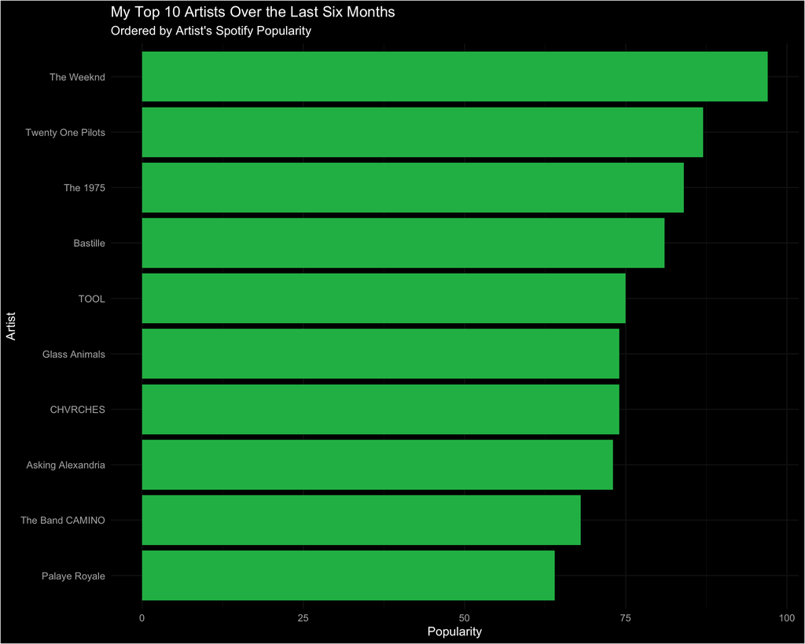

```r
library(ggdark)

my_top_artists_tbl %>%
  mutate(
    my_ranking = row_number(),
    name = name %>% as_factor() %>% fct_reorder(popularity)
  ) %>%
  slice(1:10) %>%
  ggplot(aes(x = popularity, y = name)) +
  geom_col(fill = "#1DB954") +
  dark_theme_minimal() +
  labs(
    title = "My Top 10 Artists Over the Last Six Months",
    subtitle = "Ordered by Artist's Spotify Popularity",
    x = "Popularity",
    y = "Artist"
  )
```

One thing to take note of is that there already appears to be some clustering going on within this group in terms of each artists’ popularity. The Weeknd appears to be far more popular than any other artist on my list due to him being the only pop/Top 40 musician. Twenty One Pilots, The 1975 and Bastille, however, all have similar popularity levels and are all more popular than the next set of artists. Finally, Palaye Royale and The Band CAMINO are the least popular of all due to the fact that they’re just recently starting to gain popularity. This indicates to me that popularity is a variable worth including when it comes time to start clustering these artists.

### Exploring Genres

If you recall from above, the `my_top_artists_tbl` has a variable called `genre`. This is stored as a nested list, so to access each list of genres, we’ll have to do a little more manipulation.

```r
artists_genre_long_tbl <- my_top_artists_tbl %>%
  select(name, popularity, followers.total, genres) %>%
  unnest(genres)

artists_genre_long_tbl %>%
  head() %>%
  kable()
```

| name | popularity | followers.total | genres |
| --- | --- | --- | --- |
| The 1975 | 84 | 4034348 | indie pop |
| The 1975 | 84 | 4034348 | modern alternative rock |
| The 1975 | 84 | 4034348 | modern rock |
| The 1975 | 84 | 4034348 | nu gaze |
| The 1975 | 84 | 4034348 | pop |
| The 1975 | 84 | 4034348 | rock |

Now we have one row per genre per artist. Let’s use the `tidytext` package to do some basic text mining and see which genres are most common among my top artists.

```r
library(tidytext)

artists_genre_long_tbl %>%
  unnest_tokens(word, genres) %>%
  count(word, sort = TRUE) %>%
  slice(1:10) %>%
  kable()
```

| word | n |
| --- | --- |
| pop | 64 |
| rock | 59 |
| modern | 30 |
| indie | 25 |
| alternative | 19 |
| rap | 13 |
| post | 11 |
| punk | 9 |
| metalcore | 8 |
| metal | 7 |

There are some expected results in this list (pop, rock, alternative), but it appears some sub-genre modifiers have made their way onto the list as well (modern, post). We could expand this list to get a more nuanced picture of my listening, but since the counts are already getting small, I hesitate to add anything more.

Let’s turn each of these top genres into a binary variable indicating whether an artist fits that profile. Additionally, we’ll normalize `popularity` and `followers.total` so that they have a mean of 0 and standard deviation of 1. This will ensure that they don’t have undue weighting in the clustering algorithm. We’ll make use of the `recipes` and `textrecipes` packages.

```r
library(recipes)
library(textrecipes)

artists_genre_processed_tbl <- recipe(name ~ ., data = artists_genre_long_tbl) %>%
  step_tokenize(genres) %>%
  step_tokenfilter(genres, max_tokens = 10) %>%
  step_tf(genres, weight_scheme = "binary") %>%
  step_normalize(popularity, followers.total) %>%
  prep() %>%
  juice() %>%
  group_by(name, popularity, followers.total) %>%
  summarize_all(max) %>%
  ungroup() %>%
  set_names(names(.) %>% str_replace_all("\\.", "_"))
```

Let’s see how it looks.

```r
artists_genre_processed_tbl %>%
  glimpse()
```

```
## Rows: 50
## Columns: 13
## $ name                  <fct> A Boogie Wit da Hoodie, A Day To Remember, A R …
## $ popularity            <dbl> 1.306354213, 0.008374065, -0.251221964, 1.73901…
## $ followers_total       <dbl> -0.04255091, -0.36348787, -0.51250054, 4.569278…
## $ tf_genres_alternative <int> 0, 0, 0, 0, 0, 1, 0, 0, 0, 1, 0, 0, 0, 0, 0, 1,…
## $ tf_genres_indie       <int> 0, 0, 1, 0, 0, 1, 0, 0, 0, 0, 0, 0, 0, 1, 0, 1,…
## $ tf_genres_metal       <int> 0, 0, 0, 0, 0, 0, 0, 0, 0, 1, 0, 0, 0, 0, 0, 0,…
## $ tf_genres_metalcore   <int> 0, 1, 0, 0, 1, 0, 0, 0, 0, 0, 0, 1, 0, 0, 1, 0,…
## $ tf_genres_modern      <int> 0, 0, 0, 0, 0, 1, 1, 0, 0, 0, 0, 0, 0, 0, 0, 1,…
## $ tf_genres_pop         <int> 1, 1, 1, 1, 0, 1, 1, 1, 1, 0, 1, 0, 1, 1, 0, 1,…
## $ tf_genres_post        <int> 0, 0, 0, 1, 0, 0, 0, 0, 0, 1, 0, 0, 0, 0, 1, 0,…
## $ tf_genres_punk        <int> 0, 1, 0, 0, 0, 0, 0, 0, 0, 0, 1, 0, 0, 0, 0, 0,…
## $ tf_genres_rap         <int> 1, 0, 0, 0, 0, 0, 0, 0, 1, 0, 0, 0, 1, 0, 0, 0,…
## $ tf_genres_rock        <int> 0, 0, 0, 0, 0, 1, 1, 0, 0, 0, 0, 0, 0, 0, 0, 1,…
```

It looks like pop is a popular genre/sub-genre.

### K-Means Clustering

Now that we have our data in a cluster-friendly format, let’s define a functions that’s going to allow us to utilize a k-means clustering algorithm in a tidy way.

```r
kmeans_mapper <- function(data, centers = 3) {

  data %>%
    kmeans(centers = centers, nstart = 100)

}
```

What this function is going to allow us to do is to test a range of clusters (1-15) and store the results of the clustering algorithm in a tibble format. Additionally, we’re going to use the `glance()` function from the `broom` package to extract relevant metrics from the algorithm. We’ll also use the `set.seed()` function to ensure reproducible.

```r
library(broom)

set.seed(123)
kmeans_artists_mapped_tbl <- tibble(centers = 1:15) %>%
  mutate(k_means = centers %>% map(kmeans_mapper, data = artists_genre_processed_tbl %>% select(-name)),
         glance = k_means %>% map(glance))
```

I would print the `kmeans_artists_mapped_tbl`, but it’s a bunch of nested data and isn’t much to look at. Instead, we’ll extract the necessary information from each model to make a skree plot and see if there is an ideal number of clusters.

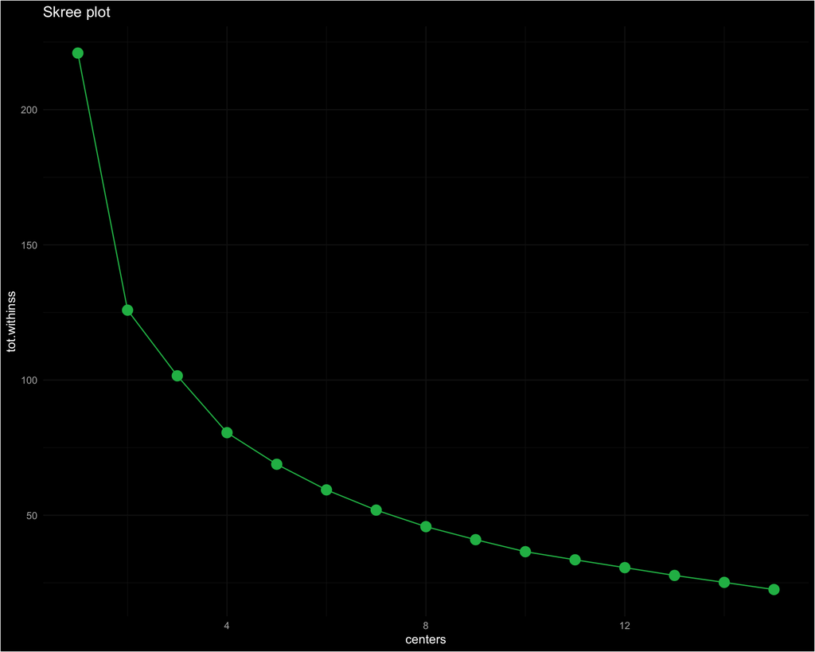

```r
kmeans_artists_mapped_tbl %>%
  unnest(glance) %>%
  select(centers, tot.withinss) %>%
  ggplot(aes(x = centers, y = tot.withinss)) +
  geom_point(color = "#1DB954", size = 4) +
  geom_line(color = "#1DB954") +
  dark_theme_minimal() +
  labs(title = "Skree plot")
```

It doesn’t look like there is a discernible “elbow” to this plot, so we’ll arbitrarily pick three. Okay, maybe it’s not totally arbitrary; I just don’t think my taste in music is that varied.

### Dimensionality Reduction

To be able to show the results of our clustering exercise, we’ll use a dimensionality reduction process to convert all of our popularity and genre data into two dimensions (for x and y axes). There are a number of reductions processes we could use including PCA and hashing, but for this analysis, we’ll use UMAP. UMAP works similarly to PCA but allows for the mapping of non-linear relationships between variables. We’ll also bind our artist names onto these new, reduced variables.

```r
library(umap)

set.seed(123)
umap_artists_obj <- artists_genre_processed_tbl %>%
  select(-name) %>%
  umap()

umap_artists_results_tbl <- umap_artists_obj$layout %>%
  as_tibble() %>%
  set_names(c("x", "y")) %>%
  bind_cols(artists_genre_processed_tbl %>%
              select(name))
umap_artists_results_tbl %>%
  head() %>%
  kable()
```

| x | y | name |
| --- | --- | --- |
| 1.4634711 | 1.7335315 | A Boogie Wit da Hoodie |
| 0.9365865 | -0.0014353 | A Day To Remember |
| 0.1630740 | -0.0522223 | A R I Z O N A |
| 2.9692410 | 2.9064339 | Ariana Grande |
| 0.0921411 | -0.5277887 | Asking Alexandria |
| -2.1475434 | -1.6090406 | AWOLNATION |

Before UMAP, we had 12 variables describing popularity and genres. Now we have two, `x` and `y`.

### Plotting the Artist Clusters

Now that we’ve done the hard work of clustering the artists and reducing the number of variables we use to describe them, now comes the fun part: visualizing the clusters. We’ll use the following chunks of code to pull the cluster information, use the `augment()` function to extract the clusters numbers and then join those cluster numbers to the UMAP-reduced variables.

```r
kmeans_artists_obj <- kmeans_artists_mapped_tbl %>%
  pull(k_means) %>%
  pluck(3)

kmeans_clusters_artists_tbl <- kmeans_artists_obj %>%
  augment(artists_genre_processed_tbl) %>%
  select(name, .cluster)

umap_kmeans_results_artists_tbl <- umap_artists_results_tbl %>%
  left_join(kmeans_clusters_artists_tbl,
            by = "name")

umap_kmeans_results_artists_tbl %>%
  glimpse()
```

```
## Rows: 50
## Columns: 4
## $ x        <dbl> 1.46347109, 0.93658650, 0.16307397, 2.96924098, 0.09214111, …
## $ y        <dbl> 1.733531463, -0.001435302, -0.052222285, 2.906433947, -0.527…
## $ name     <fct> A Boogie Wit da Hoodie, A Day To Remember, A R I Z O N A, Ar…
## $ .cluster <fct> 2, 1, 1, 2, 1, 3, 3, 2, 2, 1, 1, 1, 2, 1, 1, 3, 1, 3, 1, 3, …
```

Before plotting, we’re going to add a `label_text` variable so that we have some nice labeling on our finished plot. We’re also going to use the `ggreepel` package to ensure that our labels are plotted in a readable way.

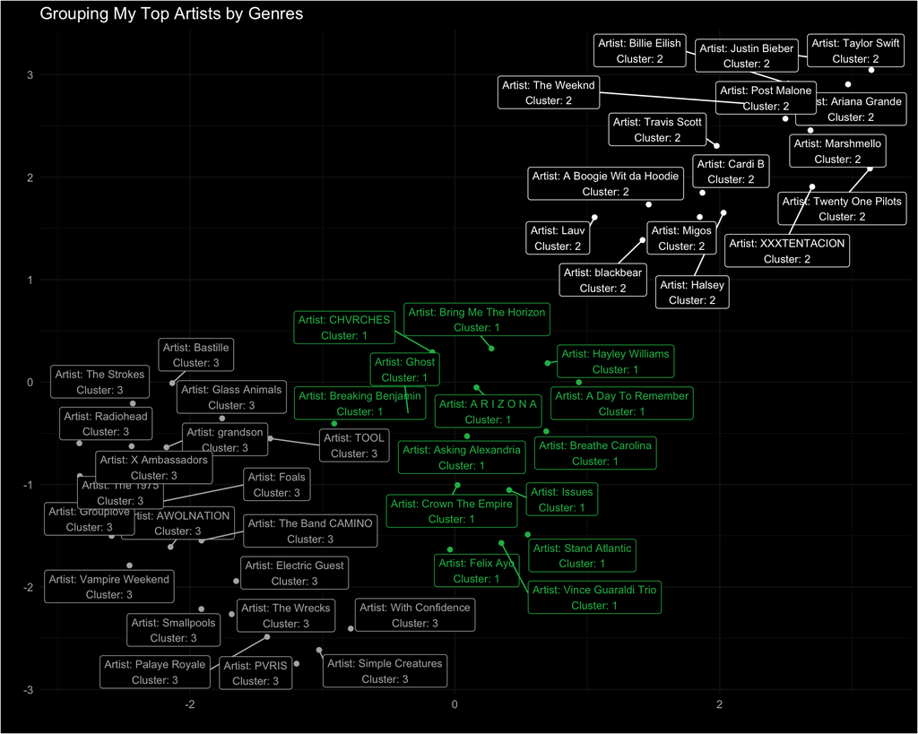

```r
library(ggrepel)

umap_kmeans_results_artists_tbl %>%
  mutate(
    label_text = str_glue("Artist: {name}\nCluster: {.cluster}")
  ) %>%
  ggplot(aes(x, y, color = .cluster)) +
  geom_point() +
  geom_label_repel(aes(label = label_text),
                   size = 3,
                   fill = "black") +
  dark_theme_minimal() +
  scale_color_manual(values = c("#1DB954", "white", "#b3b3b3")) +
  labs(
    title = "Grouping My Top Artists by Genres",
    x = "",
    y = ""
  ) +
  theme(legend.position = "none")
```

It looks like the combination of k-means and UMAP did a great job identifying some clear clusters within the data.

Cluster 1 contains some of the heavier artists, some artists I would define as “emo” and, interestingly, some classical artists. This leads me to believe that `popularity` and `followers_total` played a large part in the grouping of artists.

Cluster 2 is very clearly the popular music cluster as it contains all of the artists who have made it into the Top 40. `popularity` and `followers_total` must’ve played a big part in clustering this group, as well.

Cluster 3 is the alternative cluster. Because a lot of these artits might be found on the same playlist despite different levels of popularity, I would think that the `genre` variables probably had the most effect on this group.

Thanks for walking through this analysis with me. Check back soon for part two of this analysis where we group together my top songs using Spotify’s audio features.